# cabbages

Zoilo Franco!

Spring 2026

# Introduction

### Is there a difference in average VitC between c39 and c52 cultivation methods?

# Methods

We want to analyze VitC based on Cult method.  
VitC is numeric,Cult is categorical.  
We use the numerical~cat helper file.

$H_0$: There is no difference in VitC content of cabbages based on Cult method.

$H_A$: There is a difference in VitC content of cabbages based on Cult method.

# Results

## Descriptive Results

### Graphical Descriptive Results

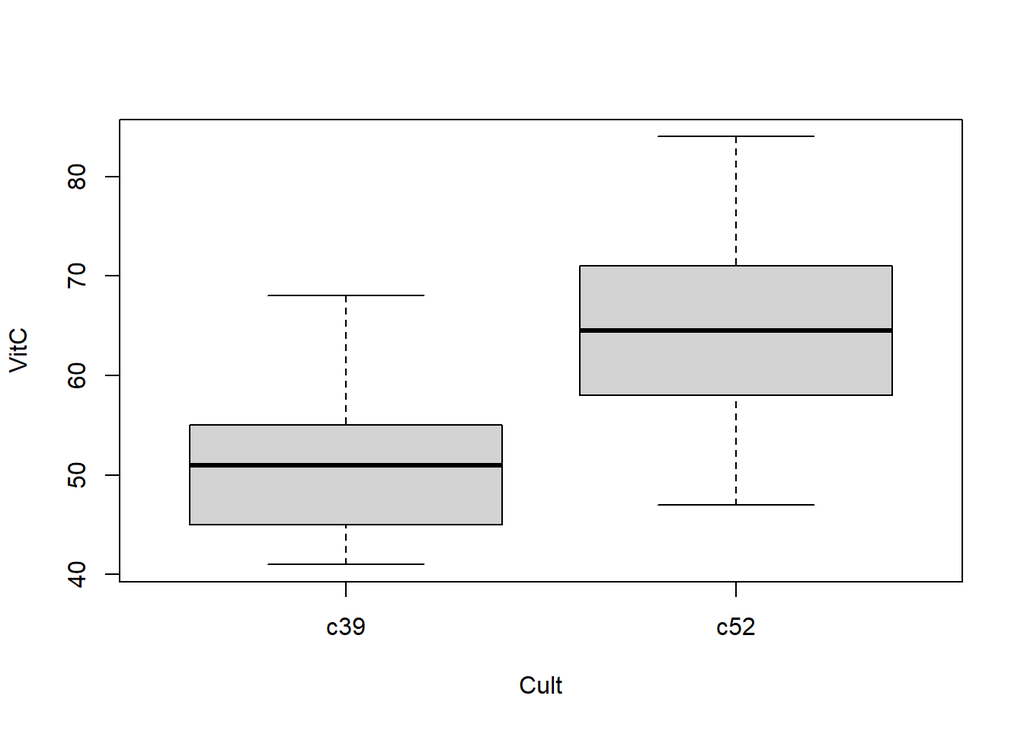

```r
boxplot(VitC~Cult,data=veggy)
```

This boxplot shows that in general, cabbages in culture c52 have in general higher levels of VitC compared to cabbages in culture c39. That the average levels on VitC content in cabbages in culture c52 is higher than VitC content in cabbages in culture c39.

### Numerical Descriptive Results

```r
describe(veggy)
```

```
## veggy
##
##  4  Variables      60  Observations
## --------------------------------------------------------------------------------
## Cult
##        n  missing distinct
##       60        0        2
##
## Value      c39 c52
## Frequency   30  30
## Proportion 0.5 0.5
## --------------------------------------------------------------------------------
## Date
##        n  missing distinct
##       60        0        3
##
## Value        d16   d20   d21
## Frequency     20    20    20
## Proportion 0.333 0.333 0.333
## --------------------------------------------------------------------------------
## HeadWt
##        n  missing distinct     Info     Mean  pMedian      Gmd      .05
##       60        0       28    0.997    2.593     2.55    1.013    1.400
##      .10      .25      .50      .75      .90      .95
##    1.590    1.875    2.550    3.125    3.820    4.205
##
## lowest : 1   1.3 1.4 1.5 1.6, highest: 3.7 3.8 4   4.2 4.3
## --------------------------------------------------------------------------------
## VitC
##        n  missing distinct     Info     Mean  pMedian      Gmd      .05
##       60        0       29    0.998    57.95     57.5    11.61    42.00
##      .10      .25      .50      .75      .90      .95
##    45.00    50.75    56.00    66.25    72.00    72.15
##
## lowest : 41 42 45 47 49, highest: 71 72 75 78 84
## --------------------------------------------------------------------------------
```

This numerical description of the veggy data shows that the least amount of VitC in a cabbage is 41 and the most amount of VitC in a cabbage is 84, and that the overall mean of VitC content is 57.95 Iu’s of VitC . That each culture group had equal amounts of cabbages.

## Inferential Results

```r
t.test(VitC~Cult,data=veggy)
```

```
##
##  Welch Two Sample t-test
##
## data:  VitC by Cult
## t = -6.3909, df = 56.376, p-value = 3.405e-08
## alternative hypothesis: true difference in means between group c39 and group c52 is not equal to 0
## 95 percent confidence interval:
##  -16.94296  -8.85704
## sample estimates:
## mean in group c39 mean in group c52
##              51.5              64.4
```

The t-test shows a p-value of 0.00000003405 which is less that 0.05. Rejects the null Hypothesis. This means we have evidence that there is a difference in the average VitC of cabbages in the different Cult. In which the average VitC of cabbages in group c52 are higher the cabbages in group c39.

# Discussion and Conclusion

The original question was whether based on culture method c39 and c52 the average amount of VitC in the cabbages shows a significant difference. Through the use of a boxplot that shows in general, group c52 having a higher average of VitC. As well as a t-test showing a p-value of 0.00000003405 which is less that 0.05. Rejecting the null Hypothesis. This means we have evidence that there is a difference in the average number of VitC in the plants based on the culture method. That cabbages in grown in the culture method c52 experienced on average a higher VitC content, compared to cabbages in the culture group c39.